# Week3

JamesDale

2/7/2020

## Quick Look

```r
head(bdims)
```

```
##   bia.di bii.di bit.di che.de che.di elb.di wri.di kne.di ank.di sho.gi che.gi
## 1   42.9   26.0   31.5   17.7   28.0   13.1   10.4   18.8   14.1  106.2   89.5
## 2   43.7   28.5   33.5   16.9   30.8   14.0   11.8   20.6   15.1  110.5   97.0
## 3   40.1   28.2   33.3   20.9   31.7   13.9   10.9   19.7   14.1  115.1   97.5
## 4   44.3   29.9   34.0   18.4   28.2   13.9   11.2   20.9   15.0  104.5   97.0
## 5   42.5   29.9   34.0   21.5   29.4   15.2   11.6   20.7   14.9  107.5   97.5
## 6   43.3   27.0   31.5   19.6   31.3   14.0   11.5   18.8   13.9  119.8   99.9
##   wai.gi nav.gi hip.gi thi.gi bic.gi for.gi kne.gi cal.gi ank.gi wri.gi age
## 1   71.5   74.5   93.5   51.5   32.5   26.0   34.5   36.5   23.5   16.5  21
## 2   79.0   86.5   94.8   51.5   34.4   28.0   36.5   37.5   24.5   17.0  23
## 3   83.2   82.9   95.0   57.3   33.4   28.8   37.0   37.3   21.9   16.9  28
## 4   77.8   78.8   94.0   53.0   31.0   26.2   37.0   34.8   23.0   16.6  23
## 5   80.0   82.5   98.5   55.4   32.0   28.4   37.7   38.6   24.4   18.0  22
## 6   82.5   80.1   95.3   57.5   33.0   28.0   36.6   36.1   23.5   16.9  21
##    wgt   hgt sex
## 1 65.6 174.0   1
## 2 71.8 175.3   1
## 3 80.7 193.5   1
## 4 72.6 186.5   1
## 5 78.8 187.2   1
## 6 74.8 181.5   1
```

```r
# Subset men and women
mdims <- subset(bdims, sex == 1)
fdims <- subset(bdims, sex == 0)
```

## Exercise 1

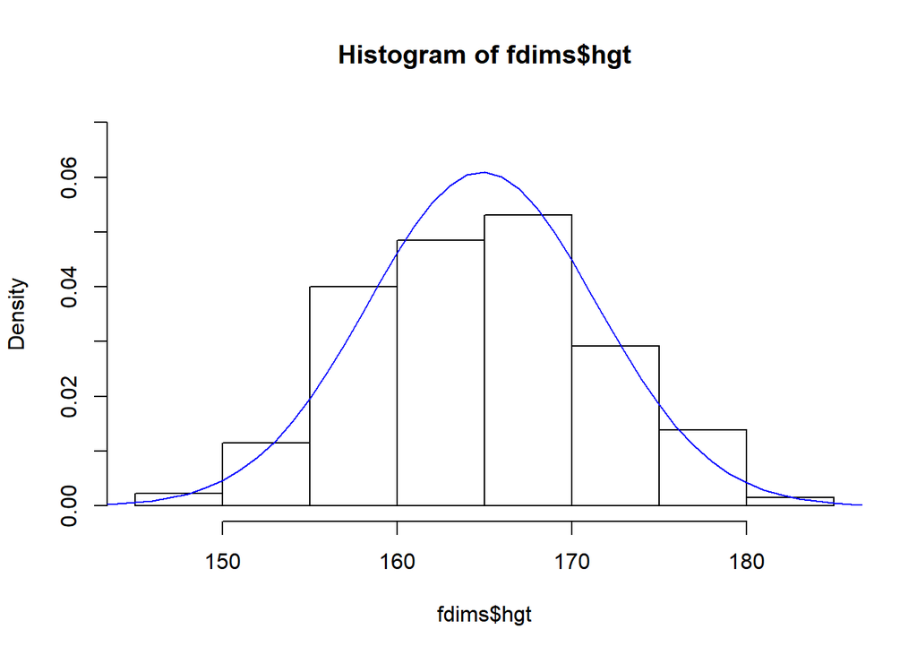

```r
# Female mean and SD
fhgtmean <- mean(fdims$hgt)
fhgtsd   <- sd(fdims$hgt)
# Plot histogram
hist(fdims$hgt, probability = TRUE, ylim = c(0, 0.07))

# x Range 140-190, y generate random based on mean and SD
#x <- min(fdims$hgt) : max(fdims$hgt)
x <- 140:190
y <- dnorm(x = x, mean = fhgtmean, sd = fhgtsd)
lines(x = x, y = y, col = "blue")
```

## Exercise 2

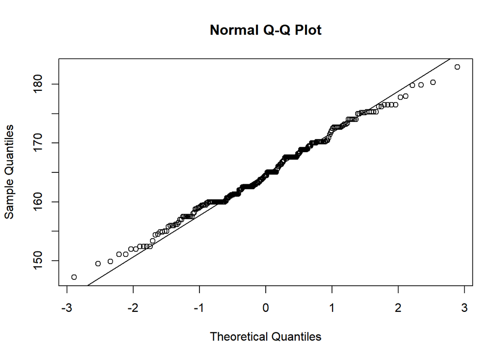

```r
# Q plot for “quantile-quantile”
qqnorm(fdims$hgt)
qqline(fdims$hgt)
```

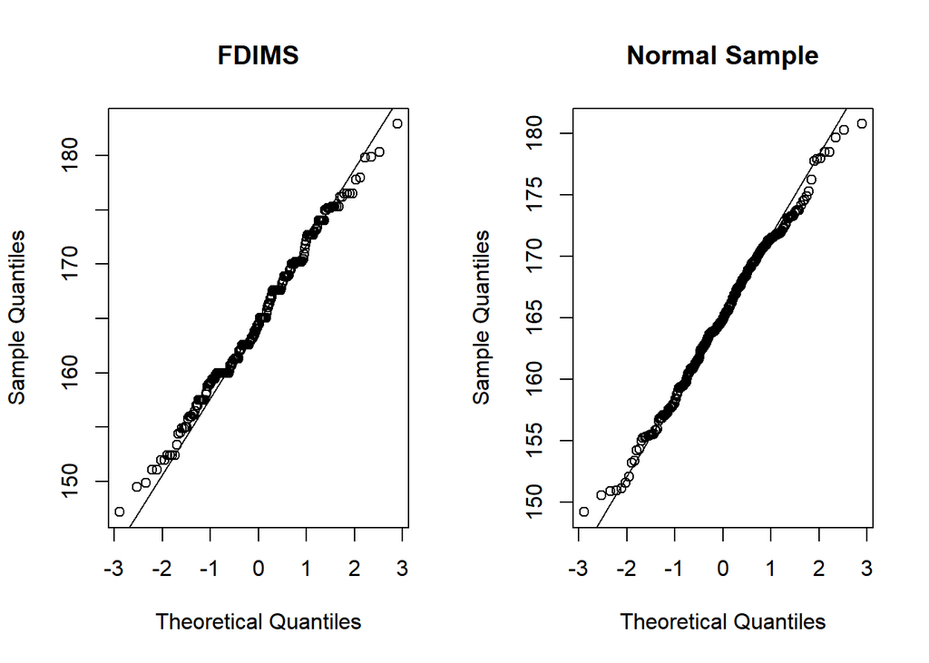

```r
# Create sample we know is normal generated by rnorm
sim_norm <- rnorm(n = length(fdims$hgt), mean = fhgtmean, sd = fhgtsd)

par(mfrow=c(1,2))
qqnorm(fdims$hgt, main = "FDIMS")
qqline(fdims$hgt)

qqnorm(sim_norm, main = "Normal Sample")
qqline(sim_norm)
```

## Exercisse 3

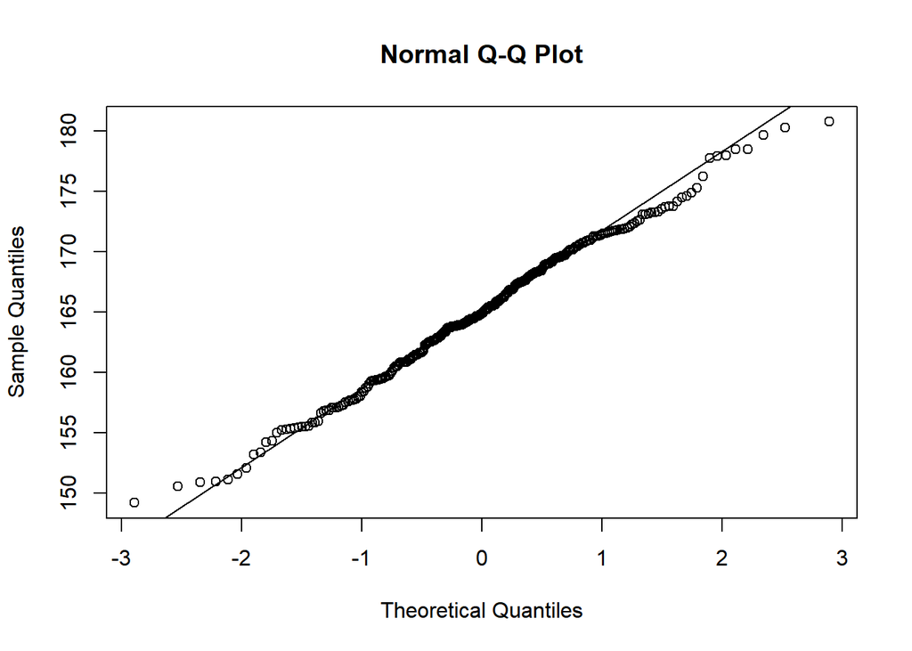

```r
# Probability plot for sim_norm
qqnorm(sim_norm)
qqline(sim_norm)
```

After plotting the sim_norm distribution it appears not all the points fall on the line. A few points deviate in on the tails but overall the distribution seems pretty tight. The plots also seem tighter in the middle of the sample norm vs fdims$hgt.

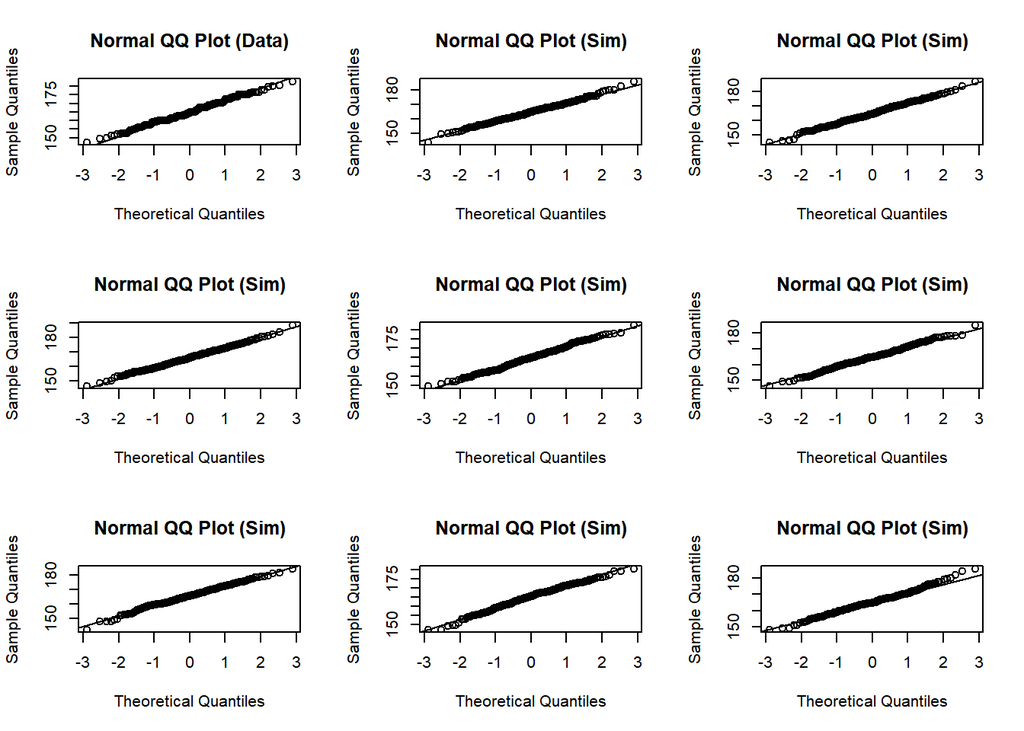

```r
qqnormsim(fdims$hgt)
```

## Exercise 4

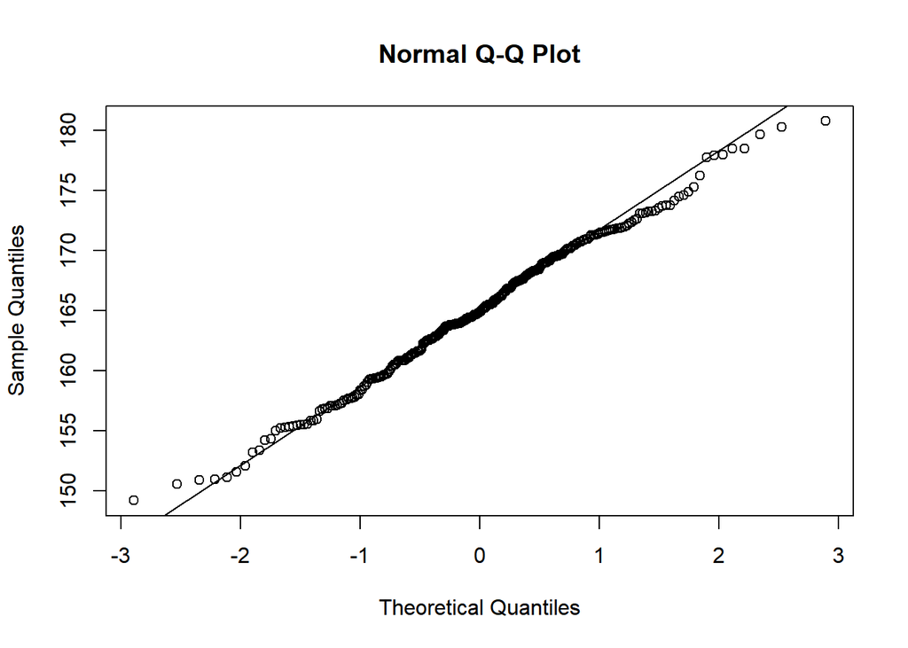

```r
qqnorm(sim_norm)
qqline(sim_norm)
```

## Exercise 5

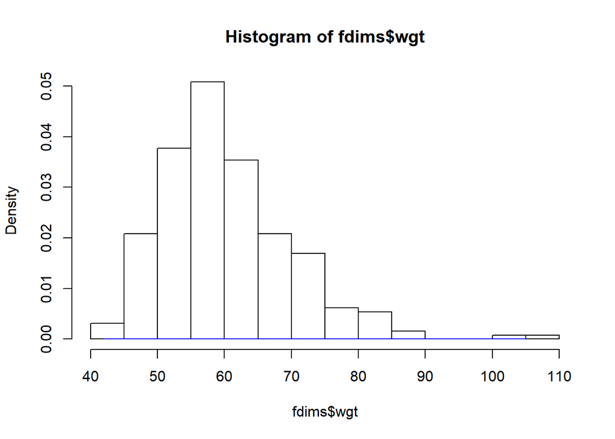

```r
# Female mean and SD
fwgtmean <- mean(fdims$wgt)
fwgtsd   <- sd(fdims$wgt)
# Plot histogram
hist(fdims$wgt, probability = TRUE)


# x Range , y generate random based on mean and SD
x <- min(fdims$wgt) : max(fdims$wgt)

y <- dnorm(x = x, mean = fhgtmean, sd = fhgtsd)
lines(x = x, y = y, col = "blue")
```

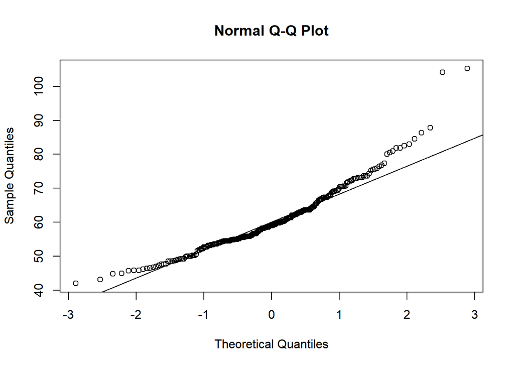

```r
# Q plot for “quantile-quantile”
qqnorm(fdims$wgt)
qqline(fdims$wgt)
```

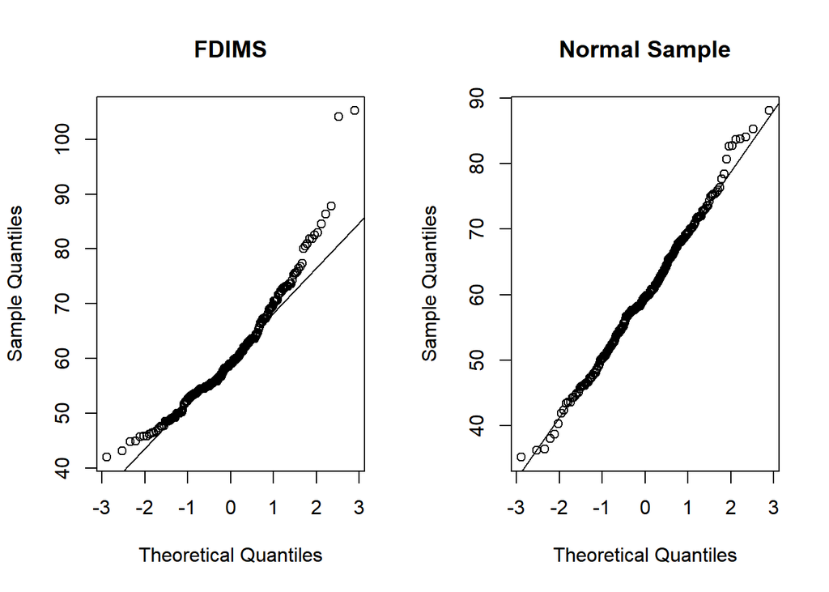

```r
# Create sample we know is normal generated by rnorm
sim_norm_wgt <- rnorm(n = length(fdims$wgt), mean = fwgtmean, sd = fwgtsd)

par(mfrow=c(1,2))
qqnorm(fdims$wgt, main = "FDIMS")
qqline(fdims$wgt)

qqnorm(sim_norm_wgt, main = "Normal Sample")
qqline(sim_norm_wgt)
```

Imediatley we can see from the histogram that the female weight data is not normally distributed. From the histogram we see the distribution shows a right skew supported by the QQ plots which show a long tail.

## Exercise 6

```r
# Calc z score
1 - pnorm(q = 182, mean = fhgtmean, sd = fhgtsd)
```

```
## [1] 0.004434387
```

```r
# Percent of observations fall above 182
sum(fdims$hgt > 182) / length(fdims$hgt)
```

```
## [1] 0.003846154
```

### What is the probability that a randomly chosen female is under 5’4"

#### The theoretical probability is **0.3303735** while the probability empirically is **0.3423077**.

### What is the probability that a randomly chosen female will weight more than 77 kilograms

#### The theoretical probability is **0.0440502** while the probability empirically is **0.05**.

## Activity 1

**a.** The histogram for female biiliac (pelvic) diameter (bii.di) belongs to normal probability plot letter **B**.

**b.** The histogram for female elbow diameter (elb.di) belongs to normal probability plot letter **C**.

**c.** The histogram for general age (age) belongs to normal probability plot letter **D**.

**d.** The histogram for female chest depth (che.de) belongs to normal probability plot letter **A**.

## Activity 2

The plots c and d most likely show a slight stepwise pattern because given the c is showing the distribution for age and d is showing the distribution for chest depth, the fact that these a discrete dimensions would cause the stepwise pattern.

## Activity 3

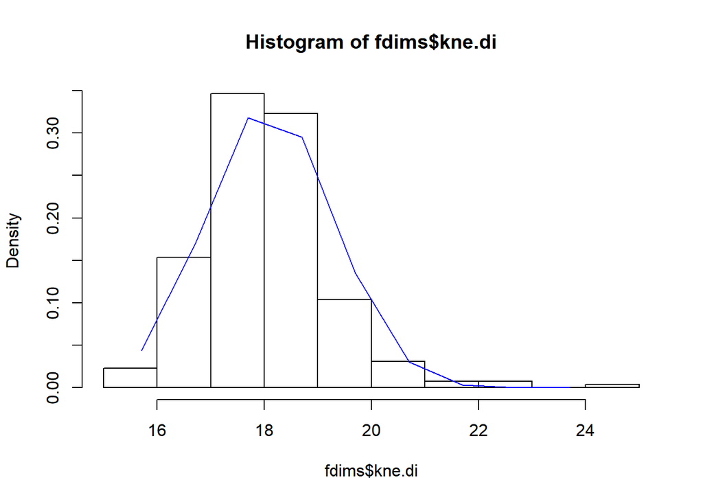

```r
knee_mean <- mean(fdims$kne.di)
knee_sd   <- sd(fdims$kne.di)
# Plot histogram
hist(fdims$kne.di, probability = TRUE)

knee_x <- min(fdims$kne.di) : max(fdims$kne.di)
knee_y <- dnorm(x = knee_x, mean = knee_mean, sd = knee_sd)
lines(x = knee_x, y = knee_y, col = "blue")
```

#### Based on the findings from the histogram above I would say the distribution is right skewed.